# Lists, Apply, and Map

2/17/2020

## Lists

<sup>Lists are a kind of vector, in which the individual elements do not need to be the same type, and in fact the elements can be vectors, matrices, and even lists. You can construct a list with the function `list()`.</sup>

```r
example <- list(42, "B", TRUE, seq(1, 7, by = 2))
example
```

```
## [[1]]
## [1] 42
##
## [[2]]
## [1] "B"
##
## [[3]]
## [1] TRUE
##
## [[4]]
## [1] 1 3 5 7
```

```r
str(example)
```

```
## List of 4
##  $ : num 42
##  $ : chr "B"
##  $ : logi TRUE
##  $ : num [1:4] 1 3 5 7
```

You can get an individual element of a list with a construction like `example[[4]]`. `example[4]` is quite similar, but actually gives a list with just the one element. The single brackets can also be used to pick a range, for example `example[3:4]`, but double brackets can only be used for a single element. If the elements have names, you can also use the name.

```r
names(example) <- c("First", "Next", "Hmm", "A_vector")
example[[4]]
```

```
## [1] 1 3 5 7
```

```r
example[4]
```

```
## $A_vector
## [1] 1 3 5 7
```

```r
example[3:4]
```

```
## $Hmm
## [1] TRUE
##
## $A_vector
## [1] 1 3 5 7
```

```r
example[["A_vector"]]
```

```
## [1] 1 3 5 7
```

```r
example[[4]][3]
```

```
## [1] 5
```

```r
example$A_vector # same as example[["A_vector"]]
```

```
## [1] 1 3 5 7
```

```r
class(example[3:4])
```

```
## [1] "list"
```

```r
class(example[4])
```

```
## [1] "list"
```

```r
class(example[["A_vector"]])
```

```
## [1] "numeric"
```

```r
class(example[[4]][3])
```

```
## [1] "numeric"
```

```r
class(example$A_vector) # same as example[["A_vector"]]
```

```
## [1] "numeric"
```

[figure not shown]

## (from Section 20.5.3 of *R for Data Science*)

As it turns out, a data frame in R is a list of vectors, all of the same length, but not necessarily of the same type.

```r
library(babynames)
head(babynames)
```

| year | sex | name | n | prop |
| --- | --- | --- | --- | --- |
| 1880 | F | Mary | 7065 | 0.0723836 |
| 1880 | F | Anna | 2604 | 0.0266790 |
| 1880 | F | Emma | 2003 | 0.0205215 |
| 1880 | F | Elizabeth | 1939 | 0.0198658 |
| 1880 | F | Minnie | 1746 | 0.0178884 |
| 1880 | F | Margaret | 1578 | 0.0161672 |

```r
head(babynames[[3]])
```

```
## [1] "Mary"      "Anna"      "Emma"      "Elizabeth" "Minnie"    "Margaret"
```

## Apply

<sup>The `apply` function is part of a family of base R functions that themselves apply functions. If x is a matrix or data.frame, `apply(x, margin, fun, ...)` applies the function `fun()` to the rows (if `margin = 1`) or columns (if `margin = 2`) of x. Any additional arguments to `fun()` go at the end.</sup>

```r
example2 <- data.frame(w = rnorm(10), x = rnorm(10, mean = 2),
  y = rnorm(10, sd = 10), z = rnorm(10, mean = -2, sd = .5))
example2[2, 1] <- NA
apply(example2, 1, mean)
```

```
##  [1] -3.33952259          NA  4.46687594 -1.38128661 -0.43697528
##  [6] -0.95101421  0.63154310  0.21689581  0.09639803  6.84464700
```

```r
apply(example2, 2, mean)
```

```
##         w         x         y         z
##        NA  2.122865  4.948945 -1.931327
```

```r
apply(example2, 1, mean, na.rm = TRUE)
```

```
##  [1] -3.33952259  6.30863048  4.46687594 -1.38128661 -0.43697528
##  [6] -0.95101421  0.63154310  0.21689581  0.09639803  6.84464700
```

```r
apply(example2, 2, function(x) mean(x) - 2)
```

```
##          w          x          y          z
##         NA  0.1228653  2.9489449 -3.9313268
```

```r
apply(example2, 1, function(x) sum(is.na(x)))
```

```
##  [1] 0 1 0 0 0 0 0 0 0 0
```

```r
apply(example2, 1, function(x) sum(is.na(x)))
```

```
##  [1] 0 1 0 0 0 0 0 0 0 0
```

`sapply()`, `vapply()`, and especially `lapply()` are generalizations of the `apply()` function. `sapply()` is a convenient way of applying a function to a list and (typically) getting a vector back:

```r
sapply(example, length)
```

```
##    First     Next      Hmm A_vector
##        1        1        1        4
```

```r
sapply(example2, length)
```

```
##  w  x  y  z
## 10 10 10 10
```

(Notice that we can use the `apply()` family of functions instead of using a `for` loop.)

## map

The `map()` family of functions in the `purrr` library (loaded as part of the tidyverse) both generalizes and simplifies the `apply()` family.

An example:

```r
library(gapminder)

gapminder %>% split(.$year) # split returns a list by dividing the first
```

```
## $`1952`
## # A tibble: 142 x 6
##    country     continent  year lifeExp      pop gdpPercap
##    <fct>       <fct>     <int>   <dbl>    <int>     <dbl>
##  1 Afghanistan Asia       1952    28.8  8425333      779.
##  2 Albania     Europe     1952    55.2  1282697     1601.
##  3 Algeria     Africa     1952    43.1  9279525     2449.
##  4 Angola      Africa     1952    30.0  4232095     3521.
##  5 Argentina   Americas   1952    62.5 17876956     5911.
##  6 Australia   Oceania    1952    69.1  8691212    10040.
##  7 Austria     Europe     1952    66.8  6927772     6137.
##  8 Bahrain     Asia       1952    50.9   120447     9867.
##  9 Bangladesh  Asia       1952    37.5 46886859      684.
## 10 Belgium     Europe     1952    68    8730405     8343.
## # … with 132 more rows
##
## $`1957`
## # A tibble: 142 x 6
##    country     continent  year lifeExp      pop gdpPercap
##    <fct>       <fct>     <int>   <dbl>    <int>     <dbl>
##  1 Afghanistan Asia       1957    30.3  9240934      821.
##  2 Albania     Europe     1957    59.3  1476505     1942.
##  3 Algeria     Africa     1957    45.7 10270856     3014.
##  4 Angola      Africa     1957    32.0  4561361     3828.
##  5 Argentina   Americas   1957    64.4 19610538     6857.
##  6 Australia   Oceania    1957    70.3  9712569    10950.
##  7 Austria     Europe     1957    67.5  6965860     8843.
##  8 Bahrain     Asia       1957    53.8   138655    11636.
##  9 Bangladesh  Asia       1957    39.3 51365468      662.
## 10 Belgium     Europe     1957    69.2  8989111     9715.
## # … with 132 more rows
##
## $`1962`
## # A tibble: 142 x 6
##    country     continent  year lifeExp      pop gdpPercap
##    <fct>       <fct>     <int>   <dbl>    <int>     <dbl>
##  1 Afghanistan Asia       1962    32.0 10267083      853.
##  2 Albania     Europe     1962    64.8  1728137     2313.
##  3 Algeria     Africa     1962    48.3 11000948     2551.
##  4 Angola      Africa     1962    34    4826015     4269.
```

[output cut: 136 more lines]

```
## $`2007`
## # A tibble: 142 x 6
##    country     continent  year lifeExp       pop gdpPercap
##    <fct>       <fct>     <int>   <dbl>     <int>     <dbl>
##  1 Afghanistan Asia       2007    43.8  31889923      975.
##  2 Albania     Europe     2007    76.4   3600523     5937.
##  3 Algeria     Africa     2007    72.3  33333216     6223.
##  4 Angola      Africa     2007    42.7  12420476     4797.
##  5 Argentina   Americas   2007    75.3  40301927    12779.
##  6 Australia   Oceania    2007    81.2  20434176    34435.
##  7 Austria     Europe     2007    79.8   8199783    36126.
##  8 Bahrain     Asia       2007    75.6    708573    29796.
##  9 Bangladesh  Asia       2007    64.1 150448339     1391.
## 10 Belgium     Europe     2007    79.4  10392226    33693.
## # … with 132 more rows
```

```r
                            # argument into groups defined by the second
```

```r
gapminder %>% split(.$year) %>%
  map(~ lm(lifeExp ~ log10(gdpPercap), weights = pop, data = .))
```

```
## $`1952`
##
## Call:
## lm(formula = lifeExp ~ log10(gdpPercap), data = ., weights = pop)
##
## Coefficients:
##      (Intercept)  log10(gdpPercap)
##           -12.81             19.75
##
##
## $`1957`
##
## Call:
## lm(formula = lifeExp ~ log10(gdpPercap), data = ., weights = pop)
##
## Coefficients:
##      (Intercept)  log10(gdpPercap)
##           -6.395            18.304
##
##
## $`1962`
##
## Call:
## lm(formula = lifeExp ~ log10(gdpPercap), data = ., weights = pop)
##
## Coefficients:
##      (Intercept)  log10(gdpPercap)
##           -9.416            19.165
##
##
## $`1967`
##
## Call:
## lm(formula = lifeExp ~ log10(gdpPercap), data = ., weights = pop)
##
## Coefficients:
##      (Intercept)  log10(gdpPercap)
##            13.09             13.41
##
##
```

[output cut: 63 more lines]

```
## lm(formula = lifeExp ~ log10(gdpPercap), data = ., weights = pop)
##
## Coefficients:
##      (Intercept)  log10(gdpPercap)
##            16.43             14.30
##
##
## $`2007`
##
## Call:
## lm(formula = lifeExp ~ log10(gdpPercap), data = ., weights = pop)
##
## Coefficients:
##      (Intercept)  log10(gdpPercap)
##            13.18             15.08
```

### Details about `map(.x, .f)`

`map()` takes a list or vector in the first position (which might come via a pipe). For the second position, it takes

```
  A function, formula, or atomic vector.
  If a function, it is used as is.
  If a formula, e.g. ~ .x + 2,
    it is converted to a function with two arguments,
    .x or . and .y. This allows you to create very
    compact anonymous functions with up to two inputs.
  If character or integer vector, e.g. "y", it is converted
    to an extractor function, function(x) x[["y"]].
    To index deeply into a nested list, use multiple
    values; c("x", "y") is equivalent to z[["x"]][["y"]].
    You can also set .null to set a default to use instead
    of NULL for absent components.
```

```r
map(example, length)
```

```
## $First
## [1] 1
##
## $Next
## [1] 1
##
## $Hmm
## [1] 1
##
## $A_vector
## [1] 4
```

```r
map(example, 1)
```

```
## $First
## [1] 42
##
## $Next
## [1] "B"
##
## $Hmm
## [1] TRUE
##
## $A_vector
## [1] 1
```

```r
map(example, 4, 2)
```

```
## $First
## NULL
##
## $Next
## NULL
##
## $Hmm
## NULL
##
## $A_vector
## [1] 7
```

- map() always returns a list.
- map_lgl() returns a logical vector
- map_int() an integer vector
- map_dbl(), a double vector
- map_chr(), a character vector

```r
gapminder %>% split(.$year) %>%
  map( ~ lm(
    lifeExp ~ log10(gdpPercap),
    weights = pop,
    data = .
  )) %>%
  map_dbl(~ coef(.x)[2])
```

```
##     1952     1957     1962     1967     1972     1977     1982     1987
## 19.75138 18.30392 19.16484 13.41348 10.70174 10.21975 10.78479 11.47050
##     1992     1997     2002     2007
## 12.04351 13.27848 14.30282 15.08101
```

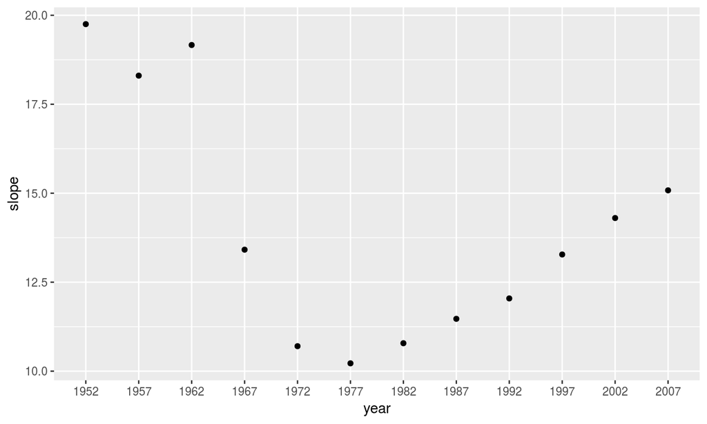

```r
gapminder %>% split(.$year) %>%
    map(~ lm(lifeExp ~ log10(gdpPercap), weights = pop, data = .)) %>%
    map_dbl(~ coef(.x)[2]) %>%
    tibble(year = names(.), slope = .) %>%
    ggplot(aes(year, slope)) + geom_point()
```

## In class exercises:

- `mtcars` is a built-in data.frame. Use the `map()` functions to get the mean of each column. Can you get those means in the form of a numeric vector?
- Use the `map()` functions to find the number of unique values for each column
- what does `map(1:5, rnorm)` give and why?

## More examples

```r
devtools::install_github("jennybc/repurrrsive")
```

[output not shown]

```r
library(repurrrsive) # a library of examples
```

```r
data(package = "repurrrsive")
```

Data sets in repurrrsive

| Item | Title |
| --- | --- |
| gap_nested | Gapminder data frame in various forms |
| gap_simple | Gapminder data frame in various forms |
| gap_split | Gapminder data frame in various forms |
| gh_repos | GitHub repos |
| gh_users | GitHub users |
| got_chars | Game of Thrones POV characters |
| sw_films | Entities from the Star Wars Universe |
| sw_people | Entities from the Star Wars Universe |
| sw_planets | Entities from the Star Wars Universe |
| sw_species | Entities from the Star Wars Universe |
| sw_starships | Entities from the Star Wars Universe |
| sw_vehicles | Entities from the Star Wars Universe |
| wesanderson | Color palettes from Wes Anderson movies |

```r
sw_people[[1]]
```

```
## $name
## [1] "Luke Skywalker"
##
## $height
## [1] "172"
##
## $mass
## [1] "77"
##
## $hair_color
## [1] "blond"
##
## $skin_color
## [1] "fair"
##
## $eye_color
## [1] "blue"
##
## $birth_year
## [1] "19BBY"
##
## $gender
## [1] "male"
##
## $homeworld
## [1] "http://swapi.co/api/planets/1/"
##
## $films
## [1] "http://swapi.co/api/films/6/" "http://swapi.co/api/films/3/"
## [3] "http://swapi.co/api/films/2/" "http://swapi.co/api/films/1/"
## [5] "http://swapi.co/api/films/7/"
##
## $species
## [1] "http://swapi.co/api/species/1/"
##
## $vehicles
## [1] "http://swapi.co/api/vehicles/14/" "http://swapi.co/api/vehicles/30/"
##
## $starships
## [1] "http://swapi.co/api/starships/12/" "http://swapi.co/api/starships/22/"
##
## $created
## [1] "2014-12-09T13:50:51.644000Z"
##
## $edited
## [1] "2014-12-20T21:17:56.891000Z"
##
## $url
## [1] "http://swapi.co/api/people/1/"
```

## How many films has each character been in?

1. First calculate for one character
2. Make it recipe
3. Use `map()` to calculate it for all characters

```r
luke <- sw_people[[1]]
length(luke$films)
```

```
## [1] 5
```

```r
rey <- sw_people[[83]]
length(rey$films)
```

```
## [1] 1
```

The recipe is then

```
~ length(.x$films)
```

Charlotte Wickham suggests thinking of `.x` as `purrr`’s pronoun

## And now using `map()`

```r
map(sw_people, ~ length(.x$films))
```

```
## [[1]]
## [1] 5
##
## [[2]]
## [1] 6
##
## [[3]]
## [1] 7
##
## [[4]]
## [1] 4
##
## [[5]]
## [1] 5
##
## [[6]]
## [1] 3
##
## [[7]]
## [1] 3
##
## [[8]]
## [1] 1
##
## [[9]]
## [1] 1
##
## [[10]]
## [1] 6
##
## [[11]]
## [1] 3
##
## [[12]]
## [1] 2
##
## [[13]]
## [1] 5
##
## [[14]]
```

[output cut: 205 more lines]

```
##
## [[83]]
## [1] 1
##
## [[84]]
## [1] 1
##
## [[85]]
## [1] 1
##
## [[86]]
## [1] 1
##
## [[87]]
## [1] 3
```

```r
map_int(sw_people, ~ length(.x$films))
```

```
##  [1] 5 6 7 4 5 3 3 1 1 6 3 2 5 4 1 3 3 1 5 5 3 1 1 2 1 2 1 1 1 1 1 3 1 2 1
## [36] 1 1 2 1 1 2 1 1 3 1 1 1 3 3 3 2 2 2 1 3 2 1 1 1 2 2 1 1 2 2 1 1 1 1 1
## [71] 1 1 2 1 1 2 1 1 2 2 1 1 1 1 1 1 3
```

```r
map_int(sw_people, ~ length(.x$films)) %>% table()
```

| 1 | 2 | 3 | 4 | 5 | 6 | 7 |
| --- | --- | --- | --- | --- | --- | --- |
| 46 | 18 | 13 | 2 | 5 | 2 | 1 |

```r
sw_people[map_int(sw_people, ~ length(.x$films)) == 7]
```

```
## [[1]]
## [[1]]$name
## [1] "R2-D2"
##
## [[1]]$height
## [1] "96"
##
## [[1]]$mass
## [1] "32"
##
## [[1]]$hair_color
## [1] "n/a"
##
## [[1]]$skin_color
## [1] "white, blue"
##
## [[1]]$eye_color
## [1] "red"
##
## [[1]]$birth_year
## [1] "33BBY"
##
## [[1]]$gender
## [1] "n/a"
##
## [[1]]$homeworld
## [1] "http://swapi.co/api/planets/8/"
##
## [[1]]$films
## [1] "http://swapi.co/api/films/5/" "http://swapi.co/api/films/4/"
## [3] "http://swapi.co/api/films/6/" "http://swapi.co/api/films/3/"
## [5] "http://swapi.co/api/films/2/" "http://swapi.co/api/films/1/"
## [7] "http://swapi.co/api/films/7/"
##
## [[1]]$species
## [1] "http://swapi.co/api/species/2/"
##
## [[1]]$created
## [1] "2014-12-10T15:11:50.376000Z"
##
## [[1]]$edited
## [1] "2014-12-20T21:17:50.311000Z"
##
## [[1]]$url
## [1] "http://swapi.co/api/people/3/"
```

```r
sw_people[map_int(sw_people, ~ length(.x$films)) == 7] %>% map_chr("name")
```

```
## [1] "R2-D2"
```

## It would have been nice to have the list have names

```r
sw_people <- sw_people %>% set_names(map_chr(sw_people, "name"))
```

## In class exercise

1. Create a character vector of hair color for Star Wars characters.
2. Create a table of hair color, sorted from most common to least common
3. Using the `sw_films` list, determine which film has the most characters.